# NIMBLE + Wrapup

Mike Li, Morgan Kain

14:55 20 November 2015

```r
library(knitr)
opts_knit$set(root.dir = "/Users/Morgan/Documents/Research/McMaster/Modeling_Work/Mike_Lunchbox/lunchbox")
```

Our goals for the final presentation are the following:  
1. Describe the use of a powerful tool for MCMC and other applications (Particle Filtering, EM)  
2. Present the steps of a validation process using a variety of methods/platforms  
3. We do not have much new “Thursday Material” so the majority of our time will be spent in R

## NIMBLE: Numerical Inference for statistical Models for Bayesian and Likelihood Estimation

NIMBLE is built in R but compiles your models and algorithms using C++ for speed  
NIMBLE is most commonly used for MCMC but can also be used to implement particle filtering and EM 1. A system for writing statistical models flexibly, which is an extension of the BUGS language  
2. A library of algorithms such as MCMC.  
3. A language, called NIMBLE, embedded within and similar in style to R, for writing  
algorithms that operate on BUGS models.

One of the most important concepts behind NIMBLE is to allow a combination of highlevel processing in R and low-level processing in compiled C++.

1. NIMBLE extracts all the declarations in the BUGS code to create a model definition.
2. From the model definition, NIMBLE builds a working model in R. This can be used to manipulate variables and operate the model from R. Operating the model includes calculating, simulating, or querying the log probability value of model nodes.
3. From the working model, NIMBLE generates customized C++ code representing the model, compiles the C++, loads it back into R, and provides an R object that interfaces to it. We often call the uncompiled model the “R-model” and the compiled model the “C-model.”

##### Why NIMBLE?

1. Options (More customizable MCMC, ability to run JAGS models and STAN models, EM, particle filter)
2. User-defined functions and distributions – written as nimbleFunctions – can be used in model code.
3. Multiple parameterizations for distributions, similar to those in R, can be used.
4. Named parameters for distributions and functions, similar to R function calls, can be used.
5. More flexible indexing of vector nodes within larger variables is allowed. For example one can place a multivariate normal vector arbitrarily within a higher-dimensional object, not just in the last index.
6. More general constraints can be declared using dconstraint, which extends the concept of JAGS’ dinterval.

#### Downloading, installing and loading NIMBLE

On Windows, you should download and install Rtools.exe available from http://cran. r-project.org/bin/windows/Rtools/. On OS X, you should install Xcode. You wil also need the make utility

After these are installed you can install NIMBLE in R using  
install.packages(“nimble”, repos = “http://r-nimble.org”, type = “source”)

Please post about installation problems to the nimble-users Google group or email nimble.stats@gmail.com.

You will also need to download STAN using the following commands  
Sys.setenv(MAKEFLAGS = “-j4”)  
install.packages(“rstan”, dependencies = TRUE)

In total you will need the following pakages:

```r
library("nimble")
library("R2jags")
library("ggplot2")
library("nimble")
library("rstan")
library("igraph")
library("parallel")
library("mcmcplots")
library("lattice")
```

#### NIMBLE Overview

**Programming in NIMBLE involves a fundamental distinction between:**  
1. the steps for an algorithm that need to happen only once, at the beginning, such as inspecting the model  
2. the steps that need to happen each time a function is called, such as MCMC iterations.  
When one writes a nimbleFunction, each of these parts can be provided separately.

Multiple parameterizations for distributions, similar to those in R, can be used. NIMBLE calls non-stochastic nodes “deterministic”, whereas BUGS calls them “logical”. NIMBLE uses “logical” in the way R does, to refer to boolean (TRUE/FALSE) variables. Alternative models can be defined from the same model code by using if-then-else statements that are evaluated when the model is defined.

### Presentation Outline

The general outline for this presentation follows along with the NIMBLE users manual  
http://r-nimble.org/documentation-2  
However, the model(s) used here are written by us

##### Part 1

1.1 Build a chain binomial model in JAGS. Conduct parameter estimation  
1.2 Translate the model into NIBLE. Conduct parameter estimation  
1.2.1 Model exploration/conversion  
1.2.2 Create a basic MCMC specification for the chain binomial, compile and run the MCMC  
1.2.3 Small MCMC specification adjustment (more on this in Part 2)  
1.3 Compare the JAGS and NIMBLE results (parameter estimates, uncertainty, convergence, computation time)  
1.4 Translate the model using a “hybrid approach” (STAN does not allow for discrete latent variables)  
1.4.1 Conduct parameter estimation using JAGS and NIMBLE  
1.4.2 Run the hybrid model in STAN and compare the results from JAGS, NIMBLE and STAN  
1.5 Compare the NIMBLE Chain Binomial and STAN hybrid model

##### Part 2

2.1 Expolore more fine-tuned adjustments that can be made in NIMBLE  
2.1.1 MCMC specifications  
2.1.2 NIMBLE functions (e.g. allows for the implementation of custom samplers)

##### Part 3

3.1 NIMBLE extras:  
3.1.1 Create, compile and run a Monte Carlo Expectation Maximization (MCEM) algorithm, which illustrates some of the flexibility NIMBLE provides to combine R and NIMBLE.  
3.1.2 Implement particle filtering for the chain binomial

### Part 1

##### 1.1 Build a chain binomial model in JAGS

First step is to construct the simulator from which we will obtain our data

Note: It will be important to set your current working directory to “../stat744/notes/NIMBLE”

Set parameters and load the Chain Binomial simulator

```r
beta <- 0.02
pop <- 100
effpropS <- 0.8
effpropI <- 0.2
reporting <- 0.5
numobs <- 20

s0 <- effpropS*pop
r0 <- 0
zerohack <- 0.001
numobs <- 20
nimtimevec <- c()
source("CBsimulator.R")
```

```
##    time  S  I  R Iobs
## 1     1 80  5  0    1
## 2     2 70 10  5    5
## 3     3 59 11 15    6
## 4     4 47 12 26    4
## 5     5 38  9 38    5
## 6     6 31  7 47    4
## 7     7 27  4 54    2
## 8     8 25  2 58    2
## 9     9 23  2 60    0
## 10   10 22  1 62    1
## 11   11 22  0 63    0
## 12   12 22  0 63    0
## 13   13 22  0 63    0
## 14   14 22  0 63    0
## 15   15 22  0 63    0
## 16   16 22  0 63    0
## 17   17 22  0 63    0
## 18   18 22  0 63    0
## 19   19 22  0 63    0
## 20   20 22  0 63    0
```

Take a peek at what this model produces

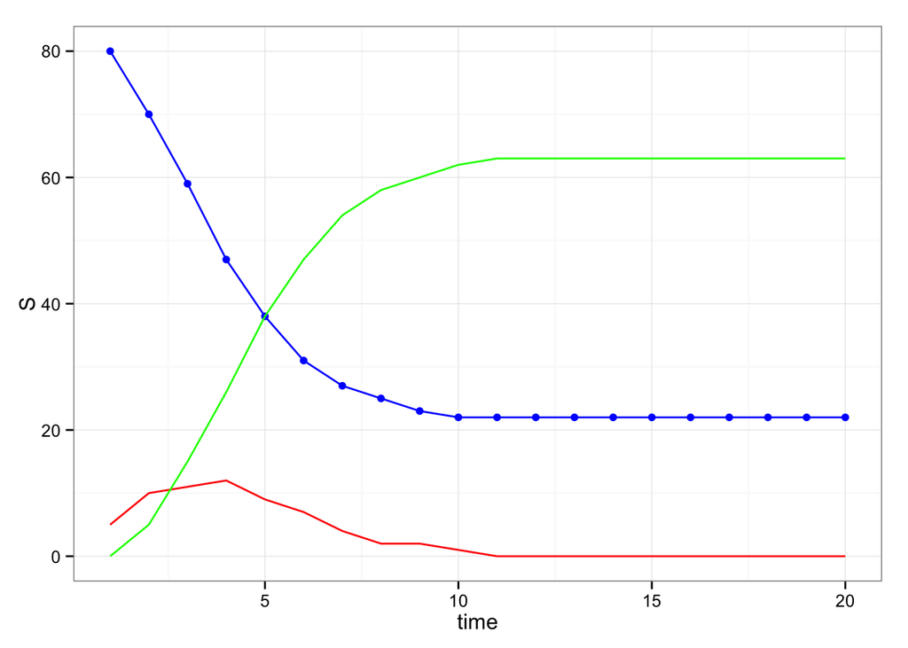

Set up the required arguments to run the JAGS model

```r
data <- list(obs = sim$Iobs,
             pop = pop,
             numobs = nrow(sim),
             r0 = r0)

inits <- list(list(
  I = sim$I*1 + 1,
  effpropS = effpropS,
  effpropI = effpropI,
  beta = beta,
  reporting = reporting),
list(
  I = sim$I*1 + 1,
  effpropS = effpropS,
  effpropI = effpropI,
  beta = beta,
  reporting = reporting),
list(
  I = sim$I*1 + 1,
  effpropS = effpropS,
  effpropI = effpropI,
  beta = beta,
  reporting = reporting)
)

params = c("beta",
           "effpropS",
           "effpropI",
           "reporting")

#rjags::set.factory("bugs::Conjugate", FALSE, type="sampler")
```

Create the model and examine the MCMC algorithms that JAGS will use to sample

```r
cbjagsmodel <- jags.model(data = data,
               inits = inits,
               file = "CB.bug",
               n.chains = length(inits))
```

```
##    Graph Size: 132
##
```

```r
list.samplers(cbjagsmodel)
```

```
## $ShiftedCount
## [1] "I[20]"
##
## $DiscreteSlicer
## [1] "I[19]"
##
## $DiscreteSlicer
## [1] "I[18]"
##
## $DiscreteSlicer
## [1] "I[17]"
##
## $DiscreteSlicer
## [1] "I[16]"
##
## $DiscreteSlicer
## [1] "I[15]"
##
## $DiscreteSlicer
## [1] "I[14]"
##
## $DiscreteSlicer
## [1] "I[13]"
##
## $DiscreteSlicer
## [1] "I[12]"
##
## $DiscreteSlicer
## [1] "I[11]"
##
## $DiscreteSlicer
## [1] "I[10]"
##
## $DiscreteSlicer
## [1] "I[9]"
##
## $DiscreteSlicer
## [1] "I[8]"
##
## $DiscreteSlicer
```

[output cut: 19 more lines]

```
##
## $DiscreteSlicer
## [1] "S[1]"
##
## $RealSlicer
## [1] "beta"
##
## $ConjugateBeta
## [1] "effpropI"
##
## $ConjugateBeta
## [1] "effpropS"
##
## $ConjugateBeta
## [1] "reporting"
```

Run some chains (could use coda::coda.samples from cbjagsmodel but here we will just run jags())

```r
jagstime <- system.time(cbjags <- jags(data = data,
               inits = inits,
               param = params,
               model.file = "CB.bug",
               n.iter = 11000,
               n.burnin = 500,
               n.thin = 20,
               n.chains = length(inits)))
```

```
## module glm loaded
```

```
##    Graph Size: 132
##
```

```r
cbjags
```

```
## Inference for Bugs model at "CB.bug", fit using jags,
##  3 chains, each with 11000 iterations (first 500 discarded), n.thin = 20
##  n.sims = 1575 iterations saved
##           mu.vect sd.vect   2.5%    25%    50%    75%  97.5%  Rhat n.eff
## beta        0.022   0.007  0.013  0.017  0.020  0.025  0.040 1.013   160
## effpropI    0.384   0.273  0.039  0.145  0.317  0.585  0.966 1.014   150
## effpropS    0.810   0.138  0.479  0.729  0.854  0.918  0.975 1.013   160
## reporting   0.490   0.119  0.309  0.399  0.474  0.560  0.762 1.002   960
## deviance   29.888   3.358 23.827 27.678 29.543 31.759 37.476 1.007   280
##
## For each parameter, n.eff is a crude measure of effective sample size,
## and Rhat is the potential scale reduction factor (at convergence, Rhat=1).
##
## DIC info (using the rule, pD = var(deviance)/2)
## pD = 5.6 and DIC = 35.5
## DIC is an estimate of expected predictive error (lower deviance is better).
```

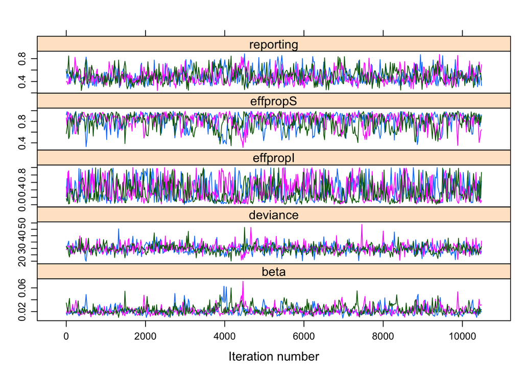

```r
xyplot(as.mcmc(cbjags))
```

##### 1.2 Build the NIMLE model

```r
source('nimCB.R')
```

Set up the model. Here we need: Constants, Data, Initial Values, NIMBLE model object

```r
nimCBdata <- list(obs = sim$Iobs)

nimCBcon <- list(numobs = numobs, pop = pop, r0 = r0)

nimCBinits <- list(I = sim$I,
                   effpropS = effpropS,
                   effpropI = effpropI,
                   beta = beta,
                   reporting = reporting,
                   s0 = s0)

nimtimevec[1] <- system.time(CBout <- nimbleModel(code = nimcode,
                         name = 'CBout',
                         constants = nimCBcon,
                         data = nimCBdata,
                         inits = nimCBinits))[3]
```

```
## defining model...
## building model...
## setting data and initial values...
## checking model...   (use nimbleModel(..., check = FALSE) to skip model check)
## model building finished
```

##### 1.2.1 Model exploration/conversion

```r
CBout$getNodeNames()
```

```
##   [1] "reporting"            "effpropS"             "effpropI"
##   [4] "beta"                 "R[1]"                 "s0"
##   [7] "lifted_d100_minus_s0" "S[1]"                 "I[1]"
##  [10] "pSI[1]"               "obs[1]"               "R[2]"
##  [13] "I[2]"                 "S[2]"                 "R[3]"
##  [16] "pSI[2]"               "obs[2]"               "I[3]"
##  [19] "S[3]"                 "R[4]"                 "pSI[3]"
##  [22] "obs[3]"               "I[4]"                 "S[4]"
##  [25] "R[5]"                 "pSI[4]"               "obs[4]"
##  [28] "I[5]"                 "S[5]"                 "R[6]"
##  [31] "pSI[5]"               "obs[5]"               "I[6]"
##  [34] "S[6]"                 "R[7]"                 "pSI[6]"
##  [37] "obs[6]"               "I[7]"                 "S[7]"
##  [40] "R[8]"                 "pSI[7]"               "obs[7]"
##  [43] "I[8]"                 "S[8]"                 "R[9]"
```

[output cut: 21 more lines]

```r
CBout$obs
```

```
##  [1] 1 5 6 4 5 4 2 2 0 1 0 0 0 0 0 0 0 0 0 0
```

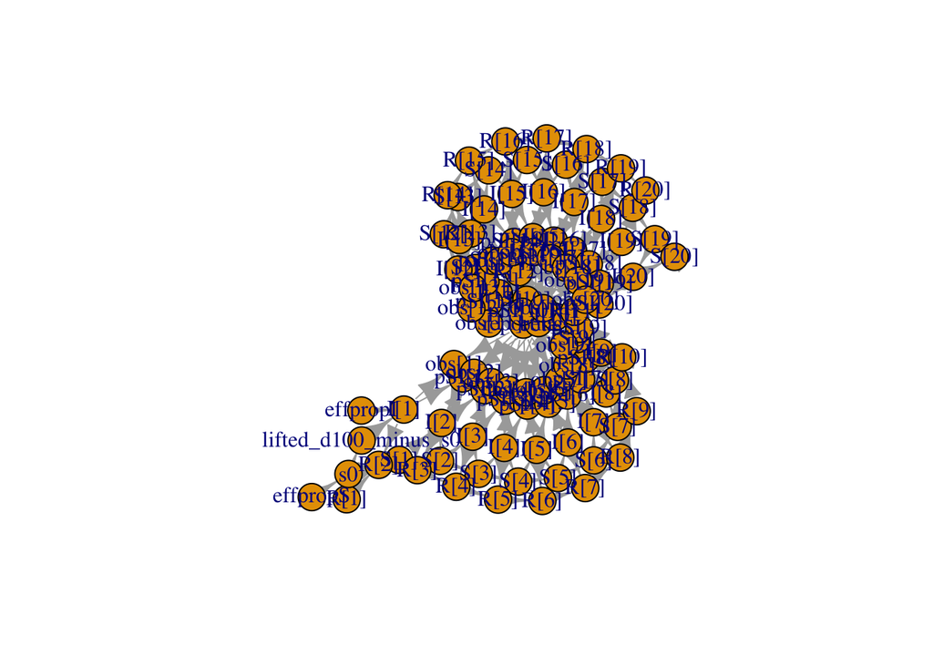

```r
par(mfrow = c(1,1))
plot(CBout$graph)
```

nimbleModel does its best to initialize a model, but let’s say you want to re-initialize I.

```r
simulate(CBout, 'I')
CBout$I
```

```
##  [1]  6  7 14  9  8  5  3  2  1  1  0  0  0  0  0  0  0  0  0  0
```

```r
CBout$getDependencies(c("beta", "effpropS", "effpropI", "reporting"))
```

```
##  [1] "reporting" "effpropS"  "effpropI"  "beta"      "s0"
##  [6] "I[1]"      "pSI[1]"    "obs[1]"    "I[2]"      "pSI[2]"
## [11] "obs[2]"    "I[3]"      "pSI[3]"    "obs[3]"    "I[4]"
## [16] "pSI[4]"    "obs[4]"    "I[5]"      "pSI[5]"    "obs[5]"
## [21] "I[6]"      "pSI[6]"    "obs[6]"    "I[7]"      "pSI[7]"
## [26] "obs[7]"    "I[8]"      "pSI[8]"    "obs[8]"    "I[9]"
## [31] "pSI[9]"    "obs[9]"    "I[10]"     "pSI[10]"   "obs[10]"
## [36] "I[11]"     "pSI[11]"   "obs[11]"   "I[12]"     "pSI[12]"
## [41] "obs[12]"   "I[13]"     "pSI[13]"   "obs[13]"   "I[14]"
## [46] "pSI[14]"   "obs[14]"   "I[15]"     "pSI[15]"   "obs[15]"
## [51] "I[16]"     "pSI[16]"   "obs[16]"   "I[17]"     "pSI[17]"
## [56] "obs[17]"   "I[18]"     "pSI[18]"   "obs[18]"   "I[19]"
## [61] "pSI[19]"   "obs[19]"   "I[20]"     "pSI[20]"   "obs[20]"
```

```r
CBout$getDependencies(c("beta", "effpropS", "effpropI", "reporting"), determOnly = TRUE)
```

```
##  [1] "pSI[1]"  "pSI[2]"  "pSI[3]"  "pSI[4]"  "pSI[5]"  "pSI[6]"  "pSI[7]"
##  [8] "pSI[8]"  "pSI[9]"  "pSI[10]" "pSI[11]" "pSI[12]" "pSI[13]" "pSI[14]"
## [15] "pSI[15]" "pSI[16]" "pSI[17]" "pSI[18]" "pSI[19]" "pSI[20]"
```

##### 1.2.2 Compile the C++ model, build the MCMC and Run

```r
nimtimevec[2] <- system.time(CBoutC <- compileNimble(CBout))[3]
```

Configure the MCMC with the default options (we will return to customizing this setup later)

```r
nimtimevec[3] <- system.time(CBoutSpec <- configureMCMC(CBout, print = TRUE))[3]
```

```
## [1] RW sampler: reporting,  adaptive: TRUE,  adaptInterval: 200,  scale: 1
## [2] RW sampler: effpropS,  adaptive: TRUE,  adaptInterval: 200,  scale: 1
## [3] RW sampler: effpropI,  adaptive: TRUE,  adaptInterval: 200,  scale: 1
## [4] RW sampler: beta,  adaptive: TRUE,  adaptInterval: 200,  scale: 1
## [5] slice sampler: s0,  adaptive: TRUE,  adaptInterval: 200,  sliceWidth: 1,  sliceMaxSteps: 100
## [6] slice sampler: I[1],  adaptive: TRUE,  adaptInterval: 200,  sliceWidth: 1,  sliceMaxSteps: 100
## [7] slice sampler: I[2],  adaptive: TRUE,  adaptInterval: 200,  sliceWidth: 1,  sliceMaxSteps: 100
## [8] slice sampler: I[3],  adaptive: TRUE,  adaptInterval: 200,  sliceWidth: 1,  sliceMaxSteps: 100
## [9] slice sampler: I[4],  adaptive: TRUE,  adaptInterval: 200,  sliceWidth: 1,  sliceMaxSteps: 100
## [10] slice sampler: I[5],  adaptive: TRUE,  adaptInterval: 200,  sliceWidth: 1,  sliceMaxSteps: 100
## [11] slice sampler: I[6],  adaptive: TRUE,  adaptInterval: 200,  sliceWidth: 1,  sliceMaxSteps: 100
## [12] slice sampler: I[7],  adaptive: TRUE,  adaptInterval: 200,  sliceWidth: 1,  sliceMaxSteps: 100
## [13] slice sampler: I[8],  adaptive: TRUE,  adaptInterval: 200,  sliceWidth: 1,  sliceMaxSteps: 100
## [14] slice sampler: I[9],  adaptive: TRUE,  adaptInterval: 200,  sliceWidth: 1,  sliceMaxSteps: 100
## [15] slice sampler: I[10],  adaptive: TRUE,  adaptInterval: 200,  sliceWidth: 1,  sliceMaxSteps: 100
## [16] slice sampler: I[11],  adaptive: TRUE,  adaptInterval: 200,  sliceWidth: 1,  sliceMaxSteps: 100
## [17] slice sampler: I[12],  adaptive: TRUE,  adaptInterval: 200,  sliceWidth: 1,  sliceMaxSteps: 100
## [18] slice sampler: I[13],  adaptive: TRUE,  adaptInterval: 200,  sliceWidth: 1,  sliceMaxSteps: 100
## [19] slice sampler: I[14],  adaptive: TRUE,  adaptInterval: 200,  sliceWidth: 1,  sliceMaxSteps: 100
## [20] slice sampler: I[15],  adaptive: TRUE,  adaptInterval: 200,  sliceWidth: 1,  sliceMaxSteps: 100
## [21] slice sampler: I[16],  adaptive: TRUE,  adaptInterval: 200,  sliceWidth: 1,  sliceMaxSteps: 100
## [22] slice sampler: I[17],  adaptive: TRUE,  adaptInterval: 200,  sliceWidth: 1,  sliceMaxSteps: 100
## [23] slice sampler: I[18],  adaptive: TRUE,  adaptInterval: 200,  sliceWidth: 1,  sliceMaxSteps: 100
## [24] slice sampler: I[19],  adaptive: TRUE,  adaptInterval: 200,  sliceWidth: 1,  sliceMaxSteps: 100
## [25] slice sampler: I[20],  adaptive: TRUE,  adaptInterval: 200,  sliceWidth: 1,  sliceMaxSteps: 100
```

Add chain monitors for the parameters of interest

```r
CBoutSpec$addMonitors(c("beta", "effpropS", "effpropI", "reporting"))
```

```
## thin = 1: reporting, effpropS, effpropI, beta
```

Build the MCMC

```r
nimtimevec[4] <- system.time(CBoutMCMC <- buildMCMC(CBoutSpec))[3]
nimtimevec[5] <- system.time(CBoutMCMC <- compileNimble(CBoutMCMC, project = CBout, resetFunctions = TRUE))[3]
```

```r
niter <- 11000
set.seed(0)
nimtimevec[6] <- system.time(CBoutMCMC$run(niter))[3]
```

Quick peek at time required

```r
jagstime[3]
```

```
## elapsed
##  16.501
```

```r
sum(nimtimevec[1:6], na.rm = TRUE)
```

```
## [1] 23.639
```

```r
nimtimevec[6]
```

```
## [1] 1.836
```

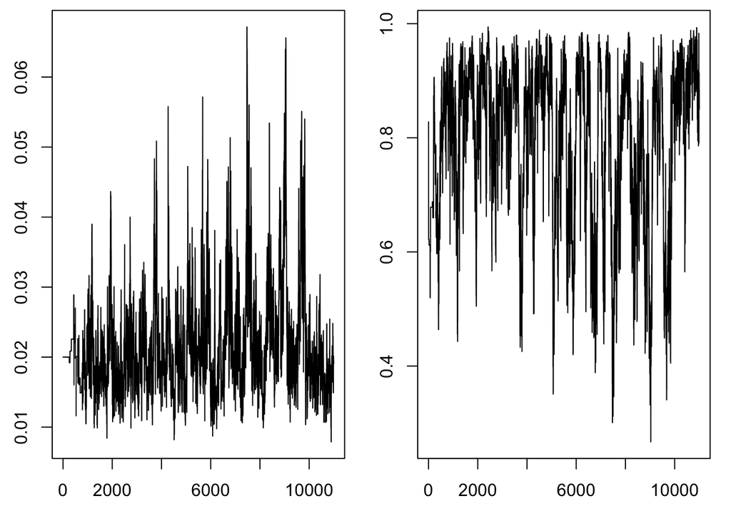

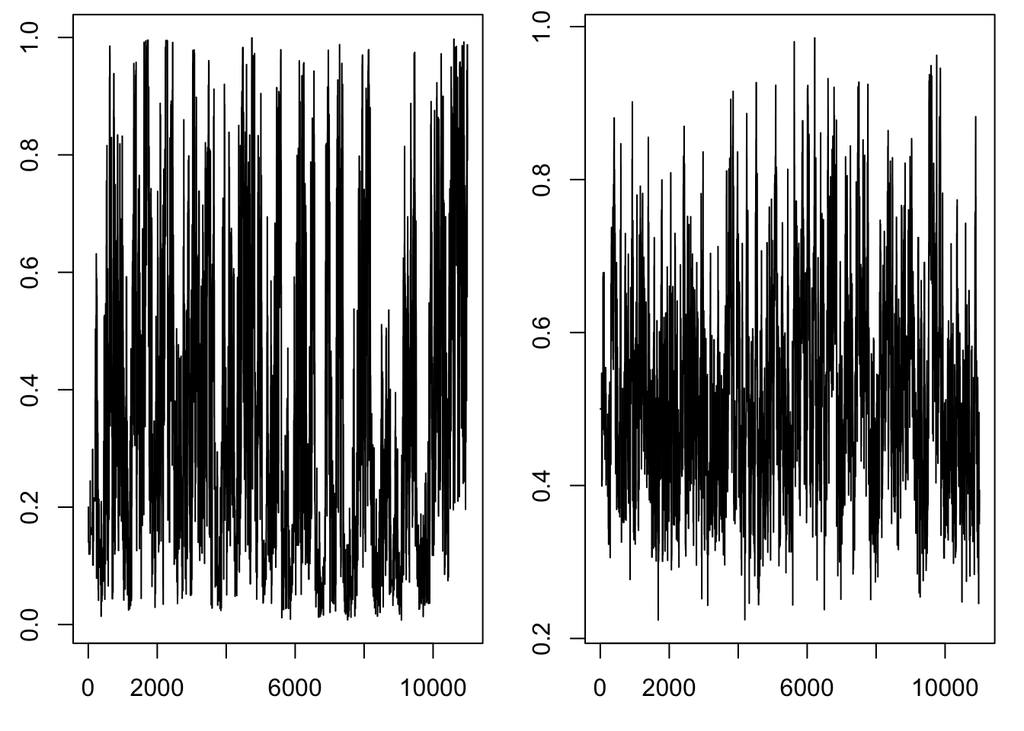

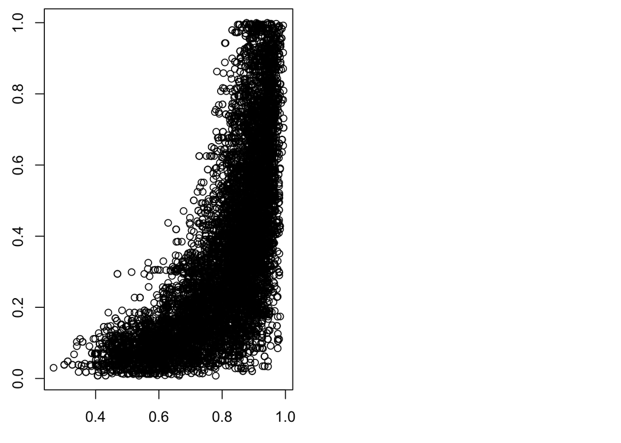

Look at the correlation in the chains

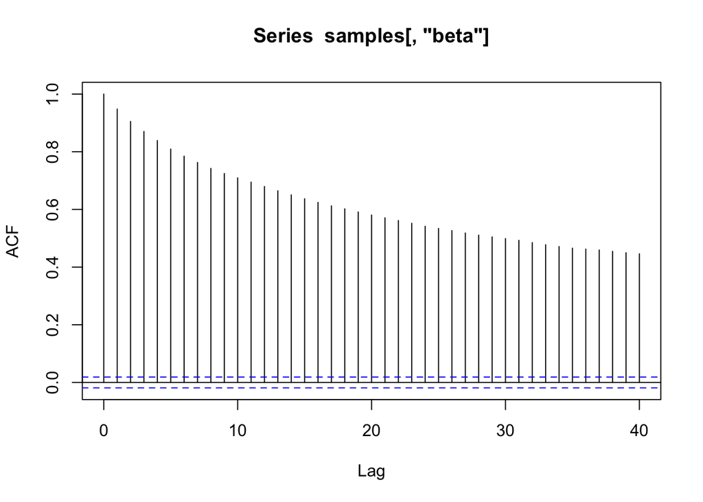

```r
  acf(samples[, "beta"])
```

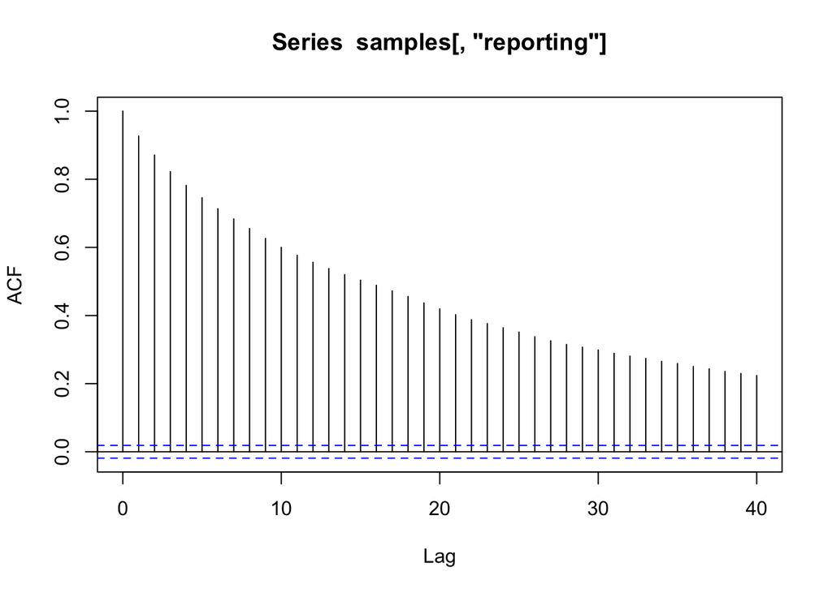

```r
  acf(samples[, "reporting"])
```

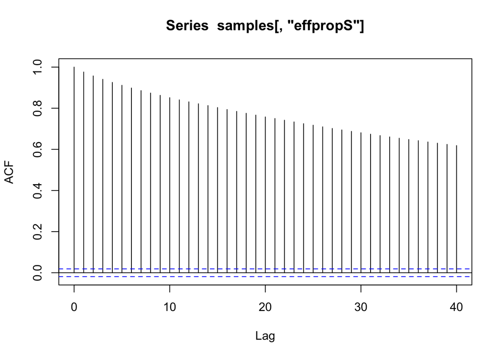

```r
  acf(samples[, "effpropS"])
```

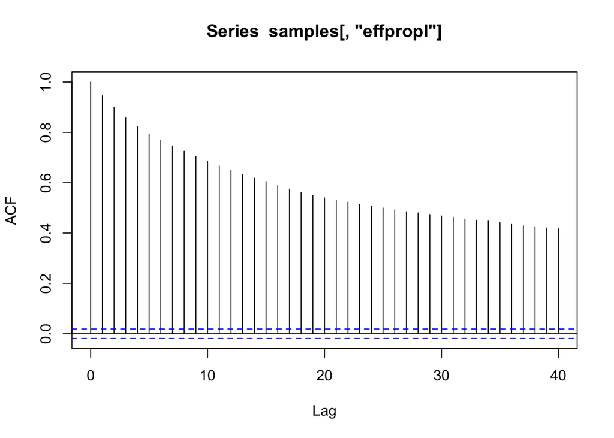

```r
  acf(samples[, "effpropI"])
```

##### 1.2.3 Small MCMC specification adjustment

A few undesirable results here… we can add a block sampler to decrease correlation

```r
CBoutSpec$addSampler(target = c('effpropS', 'effpropI'), type = 'RW_block',
                      control = list(adaptInterval = 10000))
```

```
## [26] RW_block sampler: effpropS, effpropI,  adaptive: TRUE,  adaptScaleOnly: FALSE,  adaptInterval: 10000,  scale: 1,  propCov: identity
```

```r
CBoutSpec$setThin(25)
```

```
## thin = 25: reporting, effpropS, effpropI, beta
```

```r
CBoutMCMC <- buildMCMC(CBoutSpec)
```

```r
CBoutMCMC <- compileNimble(CBoutMCMC, project  = CBout, resetFunctions = TRUE)
```

```r
CBoutMCMC$run(30000)
```

```r
samplesNew <- as.matrix(CBoutMCMC$mvSamples)
```

Check for an imporvement

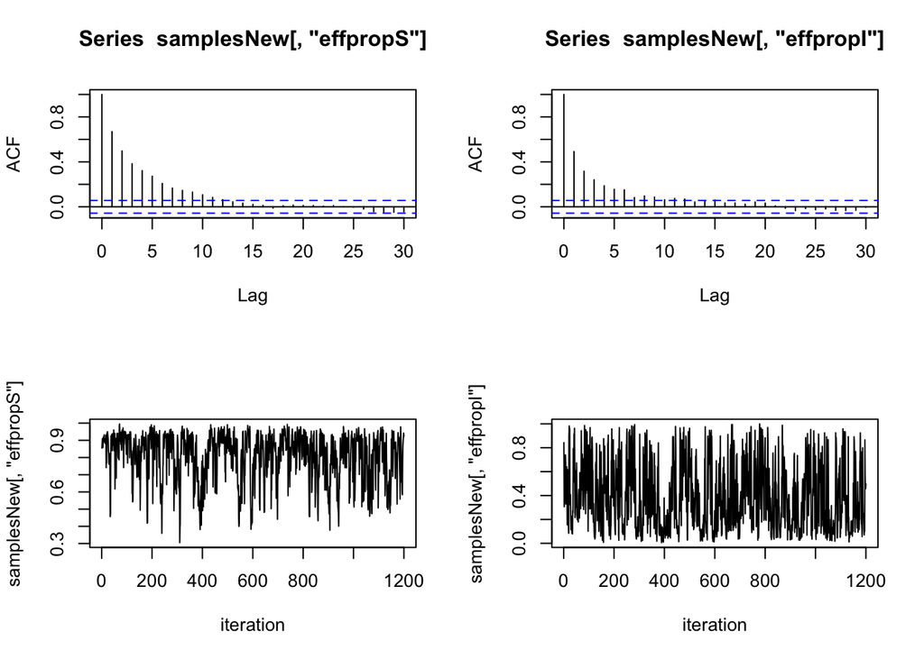

```r
  par(mfrow = c(2,2))
  acf(samplesNew[, "effpropS"])
  acf(samplesNew[, "effpropI"])
  plot(samplesNew[ , 'effpropS'], type = 'l', xlab = 'iteration')
  plot(samplesNew[ , 'effpropI'], type = 'l', xlab = 'iteration')
```

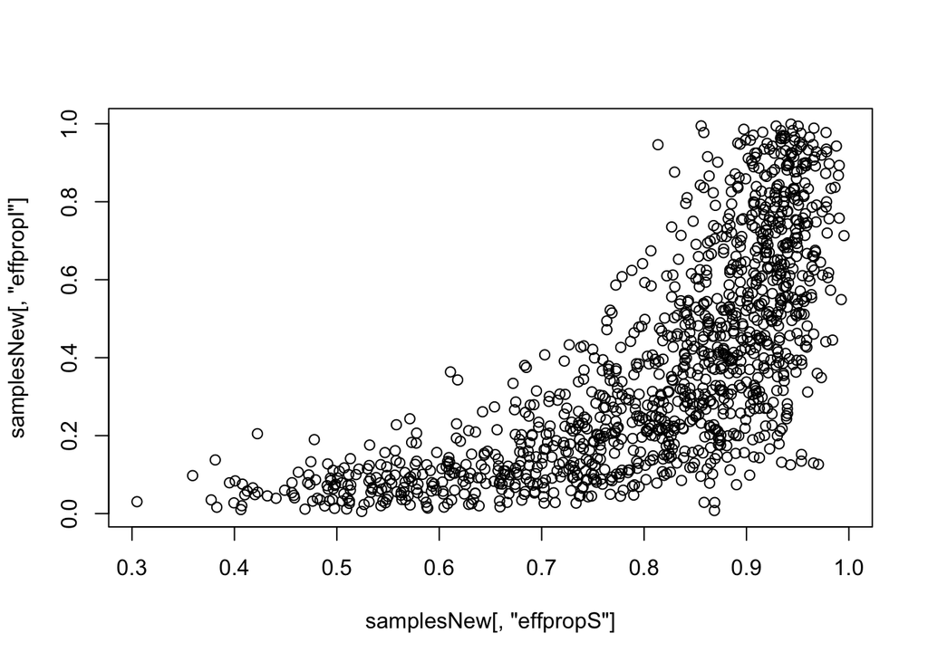

```r
  par(mfrow = c(1,1))
  plot(samplesNew[ , 'effpropS'], samplesNew[ , 'effpropI'])
```

##### 1.3 Compare the JAGS and NIMBLE results

We can also compare the NIMBLE model simultaneously with the JAGS model using MCMCsuite()

Be warned: running this code will produce about 6-8 graphs which will all pop up in separate windows!

```r
nimcb <- MCMCsuite(code = nimcode,
                   data = nimCBdata,
                   inits = nimCBinits,
                   constants = nimCBcon,
                   MCMCs = c("jags", "nimble"),
                   monitors = c("beta", "reporting", "effpropS", "effpropI"),
                   niter = 4000,
                   makePlot = FALSE,
                   savePlot = TRUE)
```

```
## defining model...
## building model...
## setting data and initial values...
## checking model...   (use nimbleModel(..., check = FALSE) to skip model check)
## model building finished
```

```
##    Graph Size: 131
##
```

##### 1.4 “hybrid approach”

But before we fit the model in STAN lets explore the hybrid model in NIMBLE

NIMBLE allows us to compare the results of multiple models even if they have different parameterizations (e.g. Chain Binomial and the Hybrid Model)

```r
data$obs <- data$obs + zerohack # Guarnantee that obs remains above 0 (important for the gamma)
data$zerohack <- zerohack

hybridjags <- jags(data = data,
               inits = inits,
               param = params,
               model.file = "hybrid.bug",
               n.iter = 8000,
               n.chains = length(inits))
```

```
##    Graph Size: 312
##
```

##### 1.4.1 Hybrid in JAGS and NIMBLE

```r
source('nimhybrid.R')
```

```r
nimhydata <- list(obs = sim$Iobs + zerohack)
nimhycon <- list(numobs = numobs, pop = pop, r0 = r0, zerohack = zerohack)

nimhyinits <- list(I = sim$I + zerohack,
                   effpropS = effpropS,
                   effpropI = effpropI,
                   beta = beta,
                   reporting = reporting,
                   s0 = s0)
```

```r
nimcb <- MCMCsuite(code = nimcode,
                   data = nimhydata,
                   inits = nimhyinits,
                   constants = nimhycon,
                   MCMCs = c("jags", "nimble"),
                   monitors = c("beta", "reporting", "effpropS", "effpropI"),
                   niter = 4000,
                   makePlot = FALSE,
                   savePlot = TRUE)
```

```
## defining model...
## building model...
## setting data and initial values...
## checking model...   (use nimbleModel(..., check = FALSE) to skip model check)
## model building finished
```

```
##    Graph Size: 316
##
```

##### 1.4.2 Hybrid in JAGS, NIMBLE and STAN

Run the STAN model

```r
stantime <- system.time (s1 <- stan(file='hybrid.stan', data = data, init = inits,
           pars=c("beta", "reporting", "effpropS", "effpropI", "I"), iter = 8000,
           seed = 1001, chains = length(inits)))
```

[output not shown]

[output cut: 131 more lines]

[output not shown]

Compare all three methods using the hybrid model

```r
nimhydata <- list(obs = sim$Iobs + zerohack)
nimhycon <- list(numobs = numobs, pop = pop,
                 r0 = r0, zerohack = zerohack)

nimhyinits <- list(I = sim$I + zerohack,
                   effpropS = effpropS,
                   effpropI = effpropI,
                   beta = beta,
                   reporting = reporting,
                   s0 = s0)
```

```r
allhybrids <- MCMCsuite(code = nimcode,
                   data = nimhydata,
                   inits = nimhyinits,
                   constants = nimhycon,
                   stan_model = "hybrid.stan",
                   MCMCs = c("jags", "nimble", "stan"),
                   monitors = c("beta", "reporting", "effpropS", "effpropI"),
                   niter = 10000,
                   makePlot = FALSE,
                   savePlot = TRUE)
```

[output not shown]

##### 1.5 Finally, compare the Chain Binomial NIMBLE and Hybrid STAN

```r
nimCBdata <- list(obs = sim$Iobs)
nimCBcon <- list(numobs = numobs, pop = pop, r0 = r0)

nimCBinits <- list(I = sim$I,
                   effpropS = effpropS,
                   effpropI = effpropI,
                   beta = beta,
                   reporting = reporting,
                   s0 = s0)
```

```r
nimcb <- MCMCsuite(code = nimcode,
                   data = nimCBdata,
                   inits = nimCBinits,
                   constants = nimCBcon,
                   stan_model = "hybrid.stan",
                   MCMCs = c("jags", "nimble", "stan"),
                   monitors = c("beta", "reporting", "effpropS", "effpropI"),
                   niter = 10000,
                   makePlot = TRUE,
                   savePlot = TRUE)
```

[output not shown]

### Part 2